```
                       TERRORISM IN FRANCE
```

# Introduction

Due to recent terrorist attacks in France , there has been a huge uproar and unrest in France as well as the global community.Policies related to terrorism in general has been a major topic of discussion for past few years in Europe .

A special light has been shown to the lenient refugee policies of European countries and weather it has an effect on the terrorist activities in France and other nations.

These are tough times and panic among people and governments may result in a step in the wrong direction with asylum laws in some nations . Thousands of lives depend on asylum in European nations and impromptu decisions by governments caving to sensational outbursts, islamophobia , rigid laws can have dire consequences.

With help of data taken from reliable sources we will try to make sensible conclusions regarding the general perception of effect of refugees on terrorism around the world with a special focus on the situation in France .

## Imports

```python
####### Data manipulation
import pandas as pd
import numpy as np
from scipy import stats
import geopandas as gpd


from IPython import get_ipython
ipython = get_ipython()

####### autoreload extension
if 'autoreload' not in ipython.extension_manager.loaded:
    %load_ext autoreload

%autoreload 2

####### Visualizations
from bokeh.io import curdoc, output_notebook
from bokeh.models import Slider, HoverTool
from bokeh.layouts import widgetbox, row, column
from bokeh.io import output_notebook, show, output_file
from bokeh.models import GeoJSONDataSource, LinearColorMapper, ColorBar
from bokeh.palettes import brewer
import json
from bokeh.resources import INLINE
from bokeh.io import curdoc
from bokeh.plotting import figure, ColumnDataSource

import seaborn as sns
import matplotlib.pyplot as plt

import warnings
warnings.filterwarnings('ignore')
```

## Source

The Sources for raw data used in the report are given as follows :  
World Map Shp File: https://naciscdn.org/naturalearth/110m/cultural/110m_cultural.zip  
Global Terrorism: https://gtd.terrorismdata.com/files/gtd-1970-2018/  
Global Terrorism Index 2018: https://www.economicsandpeace.org/wp-content/uploads/2020/08/Global-Terrorism-Index-2018.pdf (Using Tabula)  
France Terrorism : https://en.wikipedia.org/wiki/List_of_terrorist_incidents_in_France#20th_century  
France Refugees Population 1990-2018 : https://www.macrotrends.net/countries/FRA/france/refugee-statistics  
France Refugees by Country of Origin 2019 : https://www.asylumineurope.org/reports/country/france/statistics  
Global Refugees by Country of Origin : https://data.worldbank.org/indicator/SM.POP.REFG.OR

# Analysis

## Global Terrorism

Yearly Terrorism Data on a world map reveals that the hotspots for terrorism have been countries in the Middle East , Asia and Africa for more than a decade , with countries such as Nigeria , Iraq and Afghanistan recording more than 1000 deaths due to terrorist activities in a single calender year

|  | country | Year | deaths |
| --- | --- | --- | --- |
| 0 | Afghanistan | 1973 | 0.0 |
| 1 | Afghanistan | 1979 | 53.0 |
| 2 | Afghanistan | 1987 | 0.0 |
| 3 | Afghanistan | 1988 | 128.0 |
| 4 | Afghanistan | 1989 | 10.0 |

[output not shown]

[interactive chart not shown]

Global Terrorism Index published by Institute of Economics and Peace annually shows that the all top 10 countries with highest impact of terrorism in 2018 are from Asia and Africa

| Rank | COUNTRY | SCORE |
| --- | --- | --- |
| 1 | Afghanistan | 9.603 |
| 2 | Iraq | 9.241 |
| 3 | Nigeria | 8.597 |
| 4 | Syria | 8.006 |
| 5 | Pakistan | 7.889 |
| 6 | Somalia | 7.800 |
| 7 | India | 7.518 |
| 8 | Yemen | 7.259 |
| 9 | Philippines | 7.137 |
| 10 | Democratic Republic jof the Congo | 7.039 |

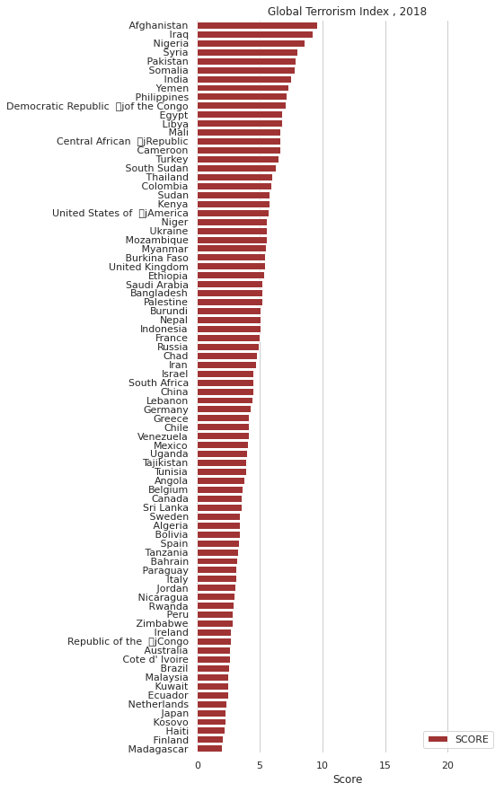

## France

Shifting our focus towards France and trends inside the country over the years .

### Terrorism in France

Terrorism incidents , deaths and injuries within France since 1990 has been (although in some years life lost due to such attacks have been drastic due to scale of incidents ) mostly on a decline for more than two decades in France .

|  | Year | Number ofincidents | Deaths | Injuries |
| --- | --- | --- | --- | --- |
| 0 | 2019 | 3 | 4 | 16 |
| 1 | 2018 | 3 | 10 | 30 |
| 2 | 2017 | 9 | 3 | 16 |
| 3 | 2016 | 12 | 89 | 451 |
| 4 | 2015 | 36 | 161 | 300 |
| 5 | 2014 | 14 | 1 | 15 |
| 6 | 2013 | 12 | 0 | 5 |
| 7 | 2012 | 65 | 8 | 8 |
| 8 | 2011 | 8 | 0 | 4 |
| 9 | 2010 | 3 | 1 | 0 |
| 10 | 2009 | 9 | 0 | 11 |
| 11 | 2008 | 13 | 0 | 1 |
| 12 | 2007 | 16 | 3 | 8 |
| 13 | 2006 | 34 | 1 | 3 |
| 14 | 2005 | 33 | 0 | 11 |
| 15 | 2004 | 11 | 0 | 10 |
| 16 | 2003 | 34 | 0 | 21 |
| 17 | 2002 | 32 | 0 | 4 |
| 18 | 2001 | 21 | 0 | 16 |
| 19 | 2000 | 28 | 4 | 1 |
| 20 | 1999 | 46 | 0 | 2 |
| 21 | 1998 | 12 | 1 | 0 |
| 22 | 1997 | 130 | 0 | 4 |
| 23 | 1996 | 270 | 18 | 114 |
| 24 | 1995 | 71 | 19 | 177 |
| 25 | 1994 | 97 | 7 | 22 |
| 26 | 1993 | 7 | 0 | 0 |
| 27 | 1992 | 126 | 9 | 12 |
| 28 | 1991 | 137 | 6 | 5 |
| 29 | 1990 | 30 | 3 | 3 |

Total Terrorism Incidents in France between 1990 - 1999.

```
Number ofincidents    926
```

Total Terrorism Incidents in France between 2000 - 2019.

[output not shown]

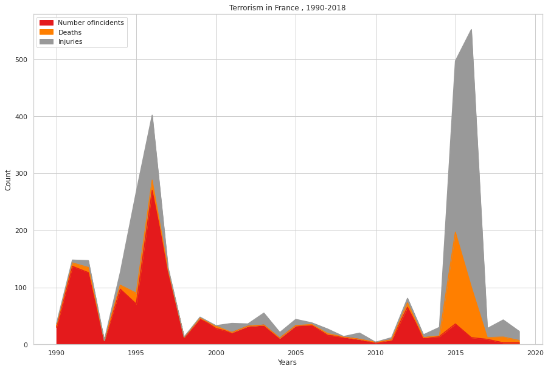

### Asylum in France

France came at 15th rank among global rankings for refugee population in 2019 (https://en.wikipedia.org/wiki/List_of_countries_by_refugee_population). France has also been a pioneer among European nations in refugee laws and equal acceptance .

For more than a decade there has been a positive change(increase) in the number of refugees granted asylum in France.

|  | Year | Refugees Granted Asylum | Annual % Change |
| --- | --- | --- | --- |
| 20 | 2010 | 200687 | 2.20 |
| 21 | 2011 | 210207 | 4.74 |
| 22 | 2012 | 217865 | 3.64 |
| 23 | 2013 | 232487 | 6.71 |
| 24 | 2014 | 252264 | 8.51 |
| 25 | 2015 | 273126 | 8.27 |
| 26 | 2016 | 304546 | 11.50 |
| 27 | 2017 | 337143 | 10.70 |
| 28 | 2018 | 368352 | 9.26 |
| 29 | 2019 | 407923 | 10.74 |

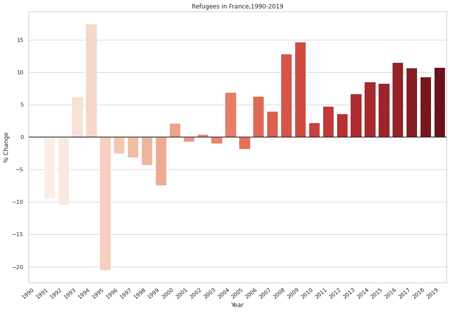

Most of the refugees taking asylum in France are from poor countries in Asia and Africa due to poor living conditions and fear of being prosecuted for reasons of race, religion, nationality, membership of a particular social group, or political opinion. These are countries with some of the worst social conditions which is a driving force of this statistics rather than location ,religion or beliefs .

|  | country of origin | First time applicants in 2019 |
| --- | --- | --- |
| 0 | Afghanistan | 9995 |
| 1 | Albania | 8010 |
| 2 | Georgia | 7735 |
| 3 | Guinea | 6600 |
| 4 | Bangladesh | 5810 |
| 5 | Ivory-Coast | 5485 |
| 6 | Haiti | 4715 |
| 7 | Nigeria | 4465 |
| 8 | Mali | 3665 |
| 9 | DRC | 4240 |

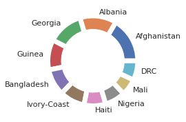

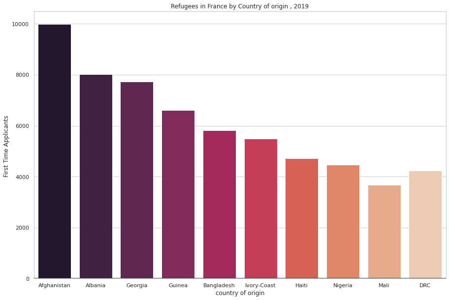

### Correlation

Observations made so far have shown no inclination towards any substantial relation between the Terrorism incidents in France and the countries' asylum policies and trends.

Infact , there is a negative relationship between the two over the past decades in France

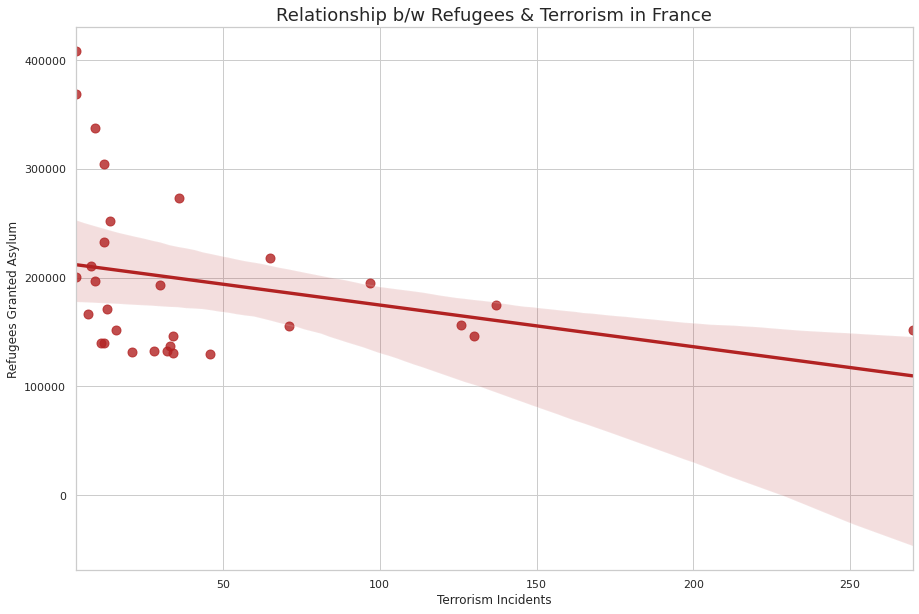

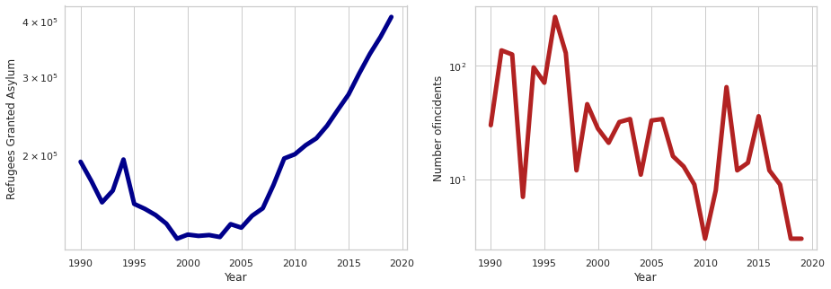

# Conclusions

[interactive chart not shown]

It is clear that people seeking asylum are mostly from the same countries which are effected by terrorism and crime worldwide .  
These are people who are desperate for help , shelter and other necessities from the global community.  
Although there are certainly cases where refugees have been the perpetrators of horrible crimes worldwide . It must not be made an example of , for pushing laws that affect the lives of millions.  
There is no direct connection amongst the two phenomenas . Sensational coverage of such topics without appropriate data and research can not be trusted nor should any major decisions be taken under mass pressure by authorities.

This report has used data analysis , visualization and correlation techniques to debunk a common perception affecting millions worldwide .  
Moving forward we need to put up a strong fight against Terrorism worldwide without any biases or pardons. Yet keeping the our moral duties towards those with needs intact and unmoved .